# Herbivory coding

## Import and wrangle data

Lets look at the data

Data summary

| Name | data |
| --- | --- |
| Number of rows | 45 |
| Number of columns | 99 |
| _______________________ |  |
| Column type frequency: |  |
| character | 82 |
| logical | 17 |
| ________________________ |  |
| Group variables | None |

**Variable type: character**

| skim_variable | n_missing | complete_rate | min | max | empty | n_unique | whitespace |
| --- | --- | --- | --- | --- | --- | --- | --- |
| item | 0 | 1.00 | 24 | 44 | 0 | 45 | 0 |
| title | 0 | 1.00 | 66 | 160 | 0 | 27 | 0 |
| wildlife_trusts_relevance | 0 | 1.00 | 4 | 4 | 0 | 1 | 0 |
| evidence_point | 0 | 1.00 | 17 | 17 | 0 | 7 | 0 |
| herbivore_species_or_simulation_exposure | 2 | 0.96 | 14 | 34 | 0 | 9 | 0 |
| horses_equines | 43 | 0.04 | 16 | 22 | 0 | 2 | 0 |
| cows_bovines | 12 | 0.73 | 6 | 26 | 0 | 11 | 0 |
| sheep_ovines | 33 | 0.27 | 6 | 21 | 0 | 4 | 0 |
| livestock_not_stated_11 | 44 | 0.02 | 23 | 23 | 0 | 1 | 0 |
| simulated_grazing_13 | 39 | 0.13 | 8 | 8 | 0 | 1 | 0 |
| mixed_herd_or_single_species_exposure | 0 | 1.00 | 6 | 15 | 0 | 3 | 0 |
| climate_effect_outcome | 1 | 0.98 | 12 | 218 | 0 | 14 | 0 |
| soil_carbon | 36 | 0.20 | 8 | 10 | 0 | 4 | 0 |
| digestive_methane_emissions_production_or_live_weight | 37 | 0.18 | 8 | 10 | 0 | 3 | 0 |
| digestive_methane_emissions_land_area | 41 | 0.09 | 9 | 9 | 0 | 2 | 0 |
| digestive_methane_emissions_per_animal | 40 | 0.11 | 8 | 10 | 0 | 4 | 0 |
| methane_flux_emissions | 34 | 0.24 | 8 | 10 | 0 | 4 | 0 |
| nitrous_oxide | 23 | 0.49 | 8 | 10 | 0 | 3 | 0 |
| co2_flux_emissions | 33 | 0.27 | 9 | 10 | 0 | 3 | 0 |
| above_ground_biomass | 42 | 0.07 | 9 | 10 | 0 | 2 | 0 |
| total_ghg_emissions_co2_equiv | 39 | 0.13 | 8 | 9 | 0 | 3 | 0 |
| root_biomass | 42 | 0.07 | 9 | 10 | 0 | 2 | 0 |
| direction_of_climate_change_outcome | 2 | 0.96 | 10 | 20 | 0 | 4 | 0 |
| herbivore_species_or_other_comparator | 0 | 1.00 | 7 | 30 | 0 | 9 | 0 |
| sheep_ovine | 35 | 0.22 | 6 | 21 | 0 | 4 | 0 |
| cows_bovine | 22 | 0.51 | 10 | 26 | 0 | 7 | 0 |
| mowing | 44 | 0.02 | 7 | 7 | 0 | 1 | 0 |
| cutting | 44 | 0.02 | 15 | 15 | 0 | 1 | 0 |
| no_herbivore_or_simulation | 35 | 0.22 | 27 | 27 | 0 | 1 | 0 |
| not_applicable | 44 | 0.02 | 15 | 15 | 0 | 1 | 0 |

[output cut: 52 more lines]

**Variable type: logical**

| skim_variable | n_missing | complete_rate | mean | count |
| --- | --- | --- | --- | --- |
| goats_caprines | 45 | 0 | NaN | : |
| deer_cervine_10 | 45 | 0 | NaN | : |
| simulated_browsing | 45 | 0 | NaN | : |
| albedo | 45 | 0 | NaN | : |
| dung_methane_emissions | 45 | 0 | NaN | : |
| wildfire | 45 | 0 | NaN | : |
| goats_caprine | 45 | 0 | NaN | : |
| horses_equine | 45 | 0 | NaN | : |
| deer_cervine_35 | 45 | 0 | NaN | : |
| not_available | 45 | 0 | NaN | : |
| global | 45 | 0 | NaN | : |
| africa | 45 | 0 | NaN | : |
| antarctica | 45 | 0 | NaN | : |
| asia | 45 | 0 | NaN | : |
| south_america_and_central_america | 45 | 0 | NaN | : |
| habitat_type_exposure | 45 | 0 | NaN | : |
| habitat_type_comparator | 45 | 0 | NaN | : |

- The data set has 45 rows and 99 columns

```
# A tibble: 11 × 2
   europe                                     n
   <chr>                                  <int>
 1 "-Ireland"                                11
 2 "-Scotland"                               10
 3 "-Wales"                                   9
 4 "-England"                                 8
 5 "-Denmark"                                 1
 6 "-France"                                  1
 7 "-France\r\n-Scotland\r\n-Switzerland"     1
 8 "-Hungary"                                 1
 9 "-Spain"                                   1
10 "-Switzerland"                             1
11  <NA>                                      1
```

## Mapping

To map locations of studies we need to

1. Extract the lat longs
2. Convert them to decimal coordinates

Lets look at the different ways in which lat-longs are recorded in the data so we can create string patterns to extract and convert the values.

The basic pattern is degrees and minutes, some have seconds - this can be represented as 1-2 digits followed by a variable number of non-digits repeated 2 or 3 times and with a compass point at the beginning or the end.

Looking at the unique contents of the `latitude_n_s` field we can also see it contains non lats (a DOI) and also other numbers which we need to remove or exclude.

The data is very messy - full of extraneous characters and extra text.

Let’s start simple - we’ll extract a list of coordinates from `latitude_n_s` and `longitude_e_w` try simple patterns

- \d{1,2}.*[NSEW] find a string which has 1 or 2 digits followed by any number of other characters and then a capital N, S, E or W
- [NSEW].*\d{1,2} as above but digits follow N, S, E, W

| refs | latitude_n_s | longitude_e_w | lats | longs |
| --- | --- | --- | --- | --- |
| Abdalla (2009) (ID:72489340) | -Latitude (state in info) 52°86' N | -Longitude (state in info) 6°54' W | 52°86' N | 6°54' W |
| Abdalla (2010) (ID:72490812) | -Latitude (state in info) 52°86' N | -Longitude (state in info) 6°54' W | 52°86' N | 6°54' W |
| Acharya (2012) (ID:72486434) | -Latitude (state in info) 56â—¦29′N | -Longitude (state in info) 9â—¦34′E | 56â—¦29′N | 9â—¦34′E |
| Allard (2007) (ID:63272782) | -Latitude (state in info) 45°38′N | -Longitude (state in info) 2°44′E | 45°38′N | 2°44′E |
| Allen (1996) (ID:72500665) | -Not available | -Not available |  |  |
| Askari (2014) (ID:72483722) | -Latitude (state in info) 20 sites between latitude 52° 8′ N and 54° 20′ N | -Longitude (state in info) 20 sites between 6° 32′ W and 8° 19′ W | 20 sites between latitude 52° 8′ N and 54° 20′ N | 20 sites between 6° 32′ W and 8° 19′ W |
| Askari (2014) EP2 (ID:74425826) | -Latitude (state in info) 20 sites between latitude 52° 8′ N and 54° 20′ N | -Longitude (state in info) 20 sites between 6° 32′ W and 8° 19′ W | 20 sites between latitude 52° 8′ N and 54° 20′ N | 20 sites between 6° 32′ W and 8° 19′ W |
| Askari (2014) EP3 (ID:74425827) | -Latitude (state in info) 20 sites between latitude 52° 8′ N and 54° 20′ N | -Longitude (state in info) 20 sites between 6° 32′ W and 8° 19′ W | 20 sites between latitude 52° 8′ N and 54° 20′ N | 20 sites between 6° 32′ W and 8° 19′ W |
| Barneze (2022) (ID:74492913) | -Latitude (state in info) 54° 1′50” N | -Longitude (state in info) 2.7° 46′30”W | 54° 1′50” N | 2.7° 46′30”W |
| Barneze (2022) (ID:74492912) | -Latitude (state in info) 54° 1′50” N | -Longitude (state in info) 2.7° 46′30”W | 54° 1′50” N | 2.7° 46′30”W |
| Barneze (2022) (ID:72462406) | -Latitude (state in info) 54° 1′50” N | -Longitude (state in info) 2.7° 46′30”W | 54° 1′50” N | 2.7° 46′30”W |
| Bell (2015) (ID:74503080) | -Latitude (state in info) 55°02.5′N | -Longitude (state in info) 3°35.3′W | 55°02.5′N | 3°35.3′W |
| Bell (2015) (ID:74503079) | -Latitude (state in info) 55°02.5′N | -Longitude (state in info) 3°35.3′W | 55°02.5′N | 3°35.3′W |
| Bell (2015) (ID:74503078) | -Latitude (state in info) 55°02.5′N | -Longitude (state in info) 3°35.3′W | 55°02.5′N | 3°35.3′W |
| Bell (2015) (ID:74503077) | -Latitude (state in info) 55°02.5′N | -Longitude (state in info) 3°35.3′W | 55°02.5′N | 3°35.3′W |
| Bell (2015) (ID:74503076) | -Latitude (state in info) 55°02.5′N | -Longitude (state in info) 3°35.3′W | 55°02.5′N | 3°35.3′W |
| Bell (2015) (ID:74503075) | -Latitude (state in info) 55°02.5′N | -Longitude (state in info) 3°35.3′W | 55°02.5′N | 3°35.3′W |
| Bell (2015) (ID:72481750) | -Latitude (state in info) 55°02.5′N | -Longitude (state in info) 3°35.3′W | 55°02.5′N | 3°35.3′W |
| Boon (2014) (ID:63272637) | -Latitude (state in info) 51â—¦0.1.11' N | -Longitude (state in info) 2â—¦55.16'W | 51â—¦0.1.11' N | 2â—¦55.16'W |
| Chiavegato (2015) (ID:72481647) | -Latitude (state in info) 44°18′N | -Longitude (state in info) 85°11′W | 44°18′N | 85°11′W |
| Clay (2010) (ID:66750519) | -Latitude (state in info) national grid ref. NY 756326, N54:41:18 W2:22:45 | -Longitude (state in info) national grid ref. NY 756326, N54:41:18 W2:22:45 | NY 756326, N54:41:18 W2:22:45 | NY 756326, N54:41:18 W2:22:45 |
| Cui (2015) (ID:72482091) | -Latitude (state in info) 20 sites located between latitudes 52 8' 12"N and 54 20' 12N". | -Longitude (state in info) 20 sites located between longitudes 6 22' 42"W and 8 16' 05"W. | 20 sites located between latitudes 52 8' 12"N and 54 20' 12N | 20 sites located between longitudes 6 22' 42"W and 8 16' 05"W |
| Czóbel (2005) (ID:72494882) | -Latitude (state in info) 46°41’N | -Longitude (state in info) 19°36’E | 46°41’N | 19°36’E |
| Díaz (2021) (ID:72326133) | -Latitude (state in info) 42â—¦51Ê¹11.41′′N | -Longitude (state in info) 2â—¦37Ê¹27.20′′W | 42â—¦51Ê¹11.41′′N | 2â—¦37Ê¹27.20′′W |
| Ford (2012) (ID:70155814) | -Latitude (state in info) 53°8′59″N | -Longitude (state in info) 4°21′1″W | 53°8′59″N | 4°21′1″W |
| Ford (2012) (ID:66931581) | -Latitude (state in info) 53 41' 15" N | -Longitude (state in info) 2 57' 4" W | 53 41' 15" N | 2 57' 4" W |
| Franz (2010) (ID:67340539) | -Not available | -Not available |  |  |
| Fraser (2014) EP1 (ID:67076153) | -Latitude (state in info) 52 25'N | -Longitude (state in info) 4 4'W | 52 25'N | 4 4'W |
| Fraser (2014) EP2 (ID:73753676) | -Latitude (state in info) 52 24' N | -Longitude (state in info) 3 44' W | 52 24' N | 3 44' W |
| Fraser (2014) EP3 (ID:73753677) | -Latitude (state in info) EXPOSURE SITE (upland):52 25' 43.76"N COMPARATOR SITE (lowland): 52 24' 05 81"N | -Longitude (state in info) EXPOSURE SITE (upland): 4 4' 9.76"W COMPARATOR SITE (lowland): 3 44' 0.81"W | EXPOSURE SITE (upland):52 25' 43.76, SITE (lowland): 52 24' 05 81 | EXPOSURE SITE (upland): 4 4' 9.76, SITE (lowland): 3 44' 0.81 |
| Fraser (2014) Evidence Point 1 (ID:67937460) | -Latitude (state in info) 51°37′N | -Longitude (state in info) 03°38′W | 51°37′N | 03°38′W |
| Fraser (2014) Evidence Point 2 (ID:73735391) | -Latitude (state in info) 51 37'N | -Longitude (state in info) 03 38'W | 51 37'N | 03 38'W |
| Fraser (2014) Evidence Point 3 (ID:73735392) | -Latitude (state in info) 51 37'N | -Longitude (state in info) 03 38'W | 51 37'N | 03 38'W |
| Marsden (2018) (ID:72475434) | -Latitude (state in info) 53°13′N | -Longitude (state in info) 4°0Ê¹W | 53°13′N | 4°0Ê¹W |
| Marsden (2019) (ID:68864156) | -Latitude (state in info) 53°22′N | -Longitude (state in info) 3°95′W | 53°22′N | 3°95′W |
| Medina-Roldán (2012) (ID:72326627) | -Latitude (state in info) 54.18°N | -Longitude (state in info) 2.36°E | 54.18°N | 2.36°E |
| Peichl (2012) (ID:70155916) | -Latitude (state in info) 52°30′N | -Longitude (state in info) 6°40′W | 52°30′N | 6°40′W |
| Rafique (2011) (ID:72487987) | -Latitude (state in info) 8 sites. Details listed here: https://link.springer.com/article/10.1007/s10021-011-9434-x/tables/1 | -Longitude (state in info) 8 sites, details listed here: https://link.springer.com/article/10.1007/s10021-011-9434-x/tables/1 |  |  |
| Renou-Wilson (2016) (ID:66931603) | -Latitude (state in info) 55 9'N | -Longitude (state in info) 7 34'W | 55 9'N | 7 34'W |
| Renou-Wilson (2016) EP2 (ID:73795432) | -Latitude (state in info) 55 9'N | -Longitude (state in info) 7 34'W | 55 9'N | 7 34'W |
| Renou-Wilson (2016) EP3 (ID:73795433) | -Latitude (state in info) 55 9'N | -Longitude (state in info) 7 34'W | 55 9'N | 7 34'W |
| Ricci (2014) EP1 (ID:72483878) | -Latitude (state in info) Hill 1: 55.87° N Hill 2: 55.85° N | -Longitude (state in info) Hill 1: 3.24° W Hill 2: 3.27° W | 1: 55.87° N, 2: 55.85° N | 1: 3.24° W, 2: 3.27° W |
| Ricci (2014) EP2 (ID:73789701) | -Latitude (state in info) Hill 1: 55.87° N Hill 2: 55.85° N | -Longitude (state in info) Hill 1: 3.24° W Hill 2: 3.27° W | 1: 55.87° N, 2: 55.85° N | 1: 3.24° W, 2: 3.27° W |
| Ricci (2014) EP3 (ID:73789702) | -Latitude (state in info) Hill 1: 55.87° N Hill 2: 55.85° N | -Longitude (state in info) Hill 1: 3.24° W Hill 2: 3.27° W | 1: 55.87° N, 2: 55.85° N | 1: 3.24° W, 2: 3.27° W |
| Sandor (2018) (ID:67341273) | -Not applicable | -Not applicable |  |  |

There are some issues here:

- Extraneous text e.g ‘20 sites between 6° 32′ W’
- Extraneous numbers e.g. 1: 55.87Â° N

Let’s try and fix these - we can clean extraneous text and numbers.

```
# A tibble: 45 × 5
   refs                            latitude_n_s              longi…¹ lats  longs
   <chr>                           <chr>                     <chr>   <chr> <chr>
 1 Abdalla (2009) (ID:72489340)    "-Latitude (state in inf… "-Long… "52Â… "6Â°…
 2 Abdalla (2010) (ID:72490812)    "-Latitude (state in inf… "-Long… "52Â… "6Â°…
 3 Acharya (2012) (ID:72486434)    "-Latitude (state in inf… "-Long… "56â… "9â—…
 4 Allard (2007) (ID:63272782)     "-Latitude (state in inf… "-Long… "45Â… "2Â°…
 5 Allen (1996) (ID:72500665)      "-Not available"          "-Not … "cha… "cha…
 6 Askari (2014) (ID:72483722)     "-Latitude (state in inf… "-Long… " be… " be…
 7 Askari (2014) EP2 (ID:74425826) "-Latitude (state in inf… "-Long… " be… " be…
 8 Askari (2014) EP3 (ID:74425827) "-Latitude (state in inf… "-Long… " be… " be…
 9 Barneze (2022) (ID:74492913)    "-Latitude (state in inf… "-Long… "54Â… "2.7…
10 Barneze (2022) (ID:74492912)    "-Latitude (state in inf… "-Long… "54Â… "2.7…
# … with 35 more rows, and abbreviated variable name ¹longitude_e_w
```

We can use these patterns to isolate the lat-longs, extract the numerical data and calculate the decimal coordinates.

```
# A tibble: 45 × 7
   refs                            lats    longs lat_p…¹ long_…² lat_c…³ long_…⁴
   <chr>                           <chr>   <chr> <chr>   <chr>   <chr>   <chr>
 1 Abdalla (2009) (ID:72489340)    "52Â°8… "6Â°… N       W       <NA>    <NA>
 2 Abdalla (2010) (ID:72490812)    "52Â°8… "6Â°… N       W       <NA>    <NA>
 3 Acharya (2012) (ID:72486434)    "56â—¦… "9â—… N       E       <NA>    <NA>
 4 Allard (2007) (ID:63272782)     "45Â°3… "2Â°… N       E       <NA>    <NA>
 5 Allen (1996) (ID:72500665)      "chara… "cha… <NA>    <NA>    <NA>    <NA>
 6 Askari (2014) (ID:72483722)     " betw… " be… N       W       <NA>    <NA>
 7 Askari (2014) EP2 (ID:74425826) " betw… " be… N       W       <NA>    <NA>
 8 Askari (2014) EP3 (ID:74425827) " betw… " be… N       W       <NA>    <NA>
 9 Barneze (2022) (ID:74492913)    "54Â° … "2.7… N       W       <NA>    2.7
10 Barneze (2022) (ID:74492912)    "54Â° … "2.7… N       W       <NA>    2.7
# … with 35 more rows, and abbreviated variable names ¹lat_point, ²long_point,
#   ³lat_cat[,1], ⁴long_cat[,1]
```

```
# A tibble: 45 × 4
# Groups:   refs, lat_point [45]
   lat_point refs                            dec_lat[,1] dec_long
   <chr>     <chr>                                 <dbl>    <dbl>
 1 N         Abdalla (2009) (ID:72489340)           53.4    -6.9
 2 N         Abdalla (2010) (ID:72490812)           53.4    -6.9
 3 N         Acharya (2012) (ID:72486434)           56.5     9.57
 4 N         Allard (2007) (ID:63272782)            45.6     2.73
 5 <NA>      Allen (1996) (ID:72500665)             NA      NA
 6 N         Askari (2014) (ID:72483722)            52.1    -6.53
 7 N         Askari (2014) EP2 (ID:74425826)        52.1    -6.53
 8 N         Askari (2014) EP3 (ID:74425827)        52.1    -6.53
 9 N         Barneze (2022) (ID:72462406)           54.0    -2.07
10 N         Barneze (2022) (ID:74492912)           54.0    -2.07
# … with 35 more rows
```

## Interactive map

[interactive chart not shown]

## Static map

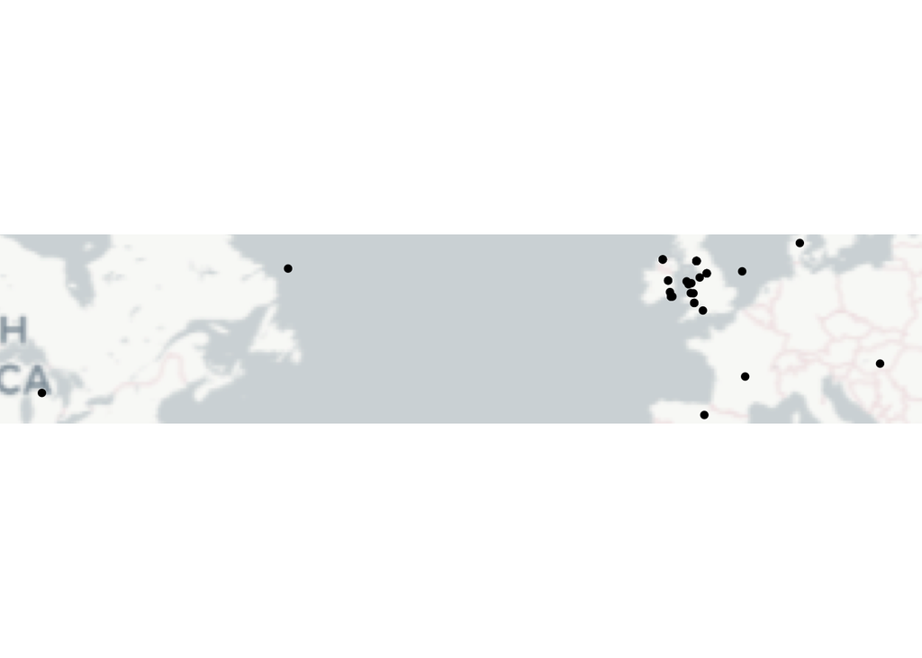